# Clase 3. Práctica EPH

# Ejercicios de práctica con variables de ingresos.

Levantar la base individual de la EPH del 1t de 2017 (Pueden tomarla de la clase 1 o usar el paquete “eph”)

Crear un dataframe con las siguientes estimaciones:

- Total ponderado de perceptores de ingresos (es decir con ingresos totales individuales mayores a 0. Variable **P47T**, ver ponderador adecuado!)
- Cantidad de perceptores de ingresos con ingreso individual total menor a $8.000
- Cantidad de perceptores de ingresos con ingreso individual total entre $8.000 y $15.000
- Cantidad de perceptores de ingresos con ingreso individual total mayor a $15.000

Estimar cuantas personas habitan en hogares con ingresos totales familiares (ITF) menores a $15.000

# Composición de Hogares

- La variable **CODUSU** distingue distintas viviendas dentro de la base de datos. O lo que es lo mismo, un mismo CODUSU permite identificar que registros corresponden a personas que habitan una misma vivienda.
- La variable **NRO_HOGAR** distingue distintos hogares dentro de una misma vivienda. Un **mismo CODUSU y mismo NRO_HOGAR** permite identificar personas que forman parte de un mismo hogar
- La variable **COMPONENTE** distingue distintas personas dentro de un hogar.

Por ejemplo, en estos 10 casos tenemos 5 hogares diferentes:

- El finalizado en **338**: Dos personas, una mujer de 75 años y un varón de 68
- El finalizado en **007**: Hogar unipersonal, varón de 69.
- El finalizado en **345**: Hogar de 3 personas. Mujer de 39, mujer de 16, varón de 9 años.

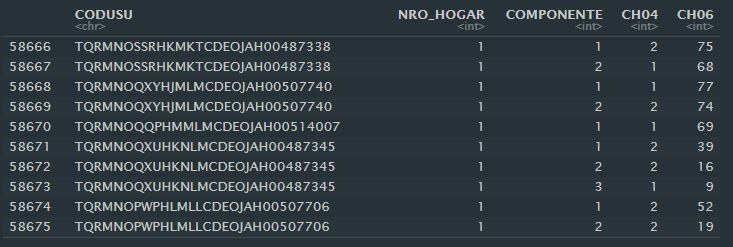

En este caso, no vemos dos hogares distintos en una misma vivienda…

Consignas:

- ¿Cuantas viviendas distintas hay en la base de datos?
- ¿Cuantos hogares distintos hay en la base de datos?
- Construir dentro de la base una variable que identifique el total de personas presentes en el hogar que habita cada individuo. Pista: La función *n()* permite contar la cantidad de registros de un determinado agrupamiento.
- ¿Cuantas personas habitan en hogares de 7 o más integrantes?
- ¿Cual es el ingreso familiar per capita en estos hogares?